# 第２回 基本操作

プログラミング演習Ⅱ

佐藤 秀保

sato0035@toyo.jp

## 先週までの内容

- Google Colab.というネット版のアプリに登録した．
  - ノートはGoogleドライブに保存
- セルにコードを入力
  - Ctrl+Enterでセルを実行
  - Ctrl+M+Bでセルを追加
  - Ctrl+M+Dでセルを削除
  - Shift+Enterでセルを実行&追加（New!)

## 準備

1. [Colab](https://colab.research.google.com/?hl=ja).にアクセス
2. 左下「ノートブックを新規作成」
3. 左上のノートブック名を「lec2」などに変更
4. 右側に「リリースノート」が出る場合は×で消す

## 基本的な演算

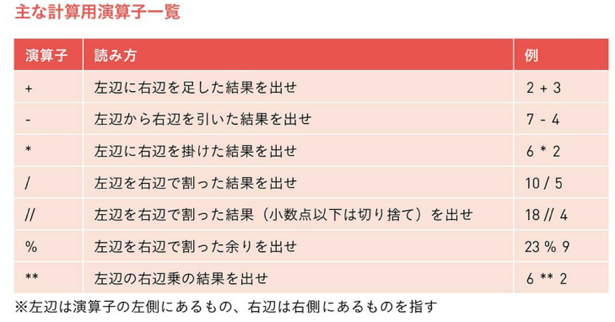

### 演算子

- 算術演算子

```python
1 + 1
1 - 1
1 * 3
2 / 2
2 ** 2 #Rでは2^2
```

このままだと最後の行しか返らない

- print関数：引数の演算結果を表示

```python
print(1 + 1)
print(1 - 1)
print(1 * 3)
print(2 / 2)
print(2 ** 2)
```

### 演算順序

```python
#括弧を先に計算
print(5 / (4 * (1 - 0.5)))
#負の数をそのままで演算可
print(1 + 1 * -5)
```

## 型 type

| 型 | R | Python | 英語フルワード |
| --- | --- | --- | --- |
| 倍精度小数点数 | `numeric` (`double`) | `float` | **float**ing point number |
| 整数 | `integer` | `int` | **int**eger |
| 論理 (真偽値) | `logical` | `bool` | **bool**ean |
| 文字列 | `character` | `str` | **str**ing |

- 2/2はfloat，1+1, 1-1, 1*3, 2**2はint

### doubleとfloatの小話

- 小数点をどこまで表示するかという実務的な問題
- 単精度：single precision floating point
  - 32ビット（有効数字約7ケタ）
- 倍精度：**double** precision floating point
  - 64ビット（有効数字約15ケタ）
- 浮動小数点 (**float**ing point)
  - 小数点の位置を「浮動」させて数値を表現する方式の概念

※pythonはfloatと呼びながらデフォで倍精度

### 計算速度の小話

- 倍精度だとあらかじめ小数点分の容量を確保している
- ゆえに，倍精度同士の演算より整数同士の演算の方が一般には速い
- しかし，pythonのintは任意の桁数を許容するので，とんでもなく大きい整数同士の演算は，有効桁数で切られる倍精度同士の小数の演算より遅い

## 代入

- 値などを保存し，使いまわす便利な方法
- = を使用（Rでは<-）

```python
text = "ハロー"
print(text)
```

### 代入のメリット

```python
zei_nuki = 100
zei_komi = zei_nuki * 1.08
print(zei_komi)
```

- 税抜き価格だけを変えればすぐに税込み価格を得られる

### 代入の注意点

- = の前後は**半角空ける**
- 代入するオブジェクトの名称は；
  - 短め，わかりやすい
  - 英文字で始まり，英文字・数字・記号 _ のみ使用可
    - Rのように**記号 . は不可**！
  - 例：牛乳Aの価格

```python
gyuunyuuAnokakaku = 100 #わかりにくい
milk_a_price = 100 #snake case!
```

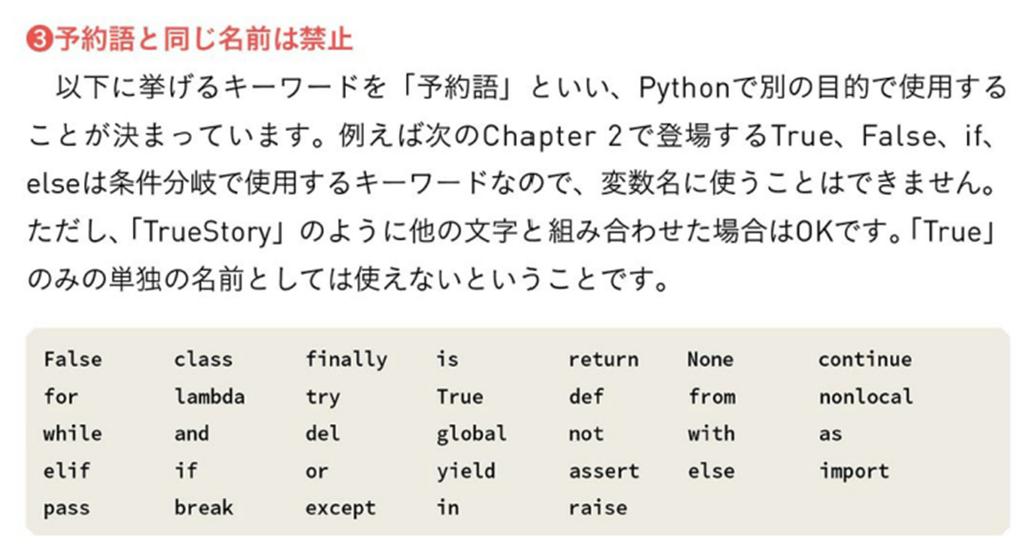

## パッケージのインストール・読込

- インストール：pip installを使用
  - ただし，Colabでは!pip
- 読み込み：import

| 操作 | R | Python |
| --- | --- | --- |
| インストール | `install.packages("tidyverse")` | `pip install pandas` |
| 読み込み | `library(tidyverse)` | `import pandas` |

- 同じノートブック内であれば，一度パッケージをインストールすれば再度する必要なし
- 同じノートブック内であれば，一度パッケージをインポートすれば，接続が切れるまでは，再度する必要なし

### pipの小話

- pipってなに？
  - **P**ip **I**nstalls **P**ackagesの略
  - ip部分は**i**nstalls **p**ackages，最初のp部分はやっぱり**P**ip
  - 再帰的頭文字（IT界隈の言葉遊びの一種）
- !pipってなに？
  - 「インストール」はcolabの深いところで命令する必要があり，!でそこを区別

### mathモジュールの読込

- パッケージとモジュールの違い
  - モジュール：関数などの集まり（１つのファイル）
  - パッケージ：モジュールの集まり
  - Rはあまり区別せず全部パッケージと呼んでいる
- mathモジュール
  - 数学でよく使い関数などがある
  - python標準ライブラリなのでインストール不要，読込のみ必要

### 関数

- モジュール名.関数（引数）

```python
import math
print(math.sqrt(4))
print(math.floor(4.1))
print(math.ceil(4.1))
print(abs(-4)) #mathモジュールじゃなくデフォで存在
```

- ルートの計算 **sq**uare **r**oo**t**
- 小数点切り捨て（床に落とす） floor
- 小数点切り上げ（天井に上げる）ceil
- 絶対値の計算 **abs**olute value

### from import 文

- モジュールから**特定の関数だけ**読み込む方法
- from モジュール名 import 関数名1, 関数名2,…と書く
- 関数使用時にモジュール名不要

```python
from math import sqrt, floor
print(sqrt(4))
print(floor(4.1))
```

### なぜモジュール名を省略できるか？

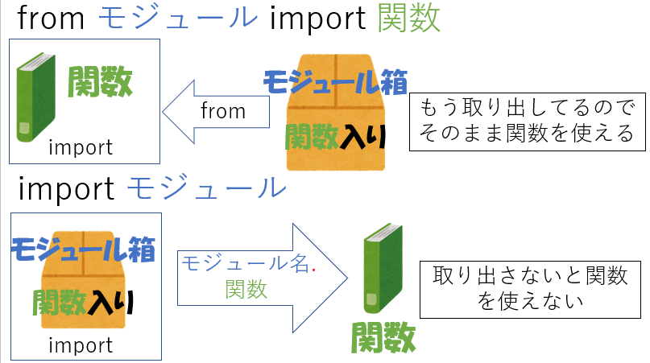

### alias（エイリアス）

- モジュール名が長いとき大変なのでalias（別名）をつけれる
- import モジュール名 as 別名
- from モジュール名 import 関数名 as 別名

```python
!pip install pandas
import pandas as pd
```

### モジュール読込の補足

- 実は，pandasはモジュール名でなくパッケージ名だが，うまいことやってくれる．
  - パッケージが定めた１つのモジュールを読み込み，そのモジュール内でパッケージにある複数のモジュールをimportしており，多くのモジュールが使えるようになる構造

## 演習

- 黄金比（美しいとされる比率で約1.618）を計算
- 定義式
  - $\frac{1 + \sqrt{5}}{2}$
- ヒント：分子を括弧でくくってから割り算すること

## 課題

- ACEの小テスト：「第２回」
- ACEのレポート：「第２回」
  - ノートブックを提出（方法は第１回資料参照）